# Framingham Heart Study Notebook

Bikramjit Das

Fall 2025

# 1 Introduction

The data is obtained from the *Framingham Heart Study*. The data set consists of 11627 observations on 39 variables which include **risk factors** used to predict 10-year risk of CHD such as *Blood Pressure, total cholesterol, LDL cholesterol, etc*. The cohort used is primarily a white middle aged population.

**Data Source:** http://biolincc.nhlbi.nih.gov/home/

**Features of the data:** * Anonymized data  
* 4434 participants  
* Three examination periods (6 years apart) from 1956-1968.  
* Participants followed for 24 years.

## 1.1 Data pre-processing

We need to preprocess the data before building the model. Let us first investigate the variables in the dataframe.

```r
#install.packages("caTools")
framing <- read.csv("framingham.csv")
str(framing)
```

```
## 'data.frame':    11627 obs. of  39 variables:
##  $ RANDID  : int  2448 2448 6238 6238 6238 9428 9428 10552 10552 11252 ...
##  $ SEX     : int  1 1 2 2 2 1 1 2 2 2 ...
##  $ TOTCHOL : int  195 209 250 260 237 245 283 225 232 285 ...
##  $ AGE     : int  39 52 46 52 58 48 54 61 67 46 ...
##  $ SYSBP   : num  106 121 121 105 108 ...
##  $ DIABP   : num  70 66 81 69.5 66 80 89 95 109 84 ...
##  $ CURSMOKE: int  0 0 0 0 0 1 1 1 1 1 ...
##  $ CIGPDAY : int  0 0 0 0 0 20 30 30 20 23 ...
##  $ BMI     : num  27 NA 28.7 29.4 28.5 ...
##  $ DIABETES: int  0 0 0 0 0 0 0 0 0 0 ...
##  $ BPMEDS  : int  0 0 0 0 0 0 0 0 0 0 ...
##  $ HEARTRTE: int  80 69 95 80 80 75 75 65 60 85 ...
##  $ GLUCOSE : int  77 92 76 86 71 70 87 103 89 85 ...
##  $ educ    : int  4 4 2 2 2 1 1 3 3 3 ...
```

[output cut: 25 more lines]

```r
head(framing)
```

```
##   RANDID SEX TOTCHOL AGE SYSBP DIABP CURSMOKE CIGPDAY   BMI DIABETES BPMEDS
## 1   2448   1     195  39 106.0  70.0        0       0 26.97        0      0
## 2   2448   1     209  52 121.0  66.0        0       0    NA        0      0
## 3   6238   2     250  46 121.0  81.0        0       0 28.73        0      0
## 4   6238   2     260  52 105.0  69.5        0       0 29.43        0      0
## 5   6238   2     237  58 108.0  66.0        0       0 28.50        0      0
## 6   9428   1     245  48 127.5  80.0        1      20 25.34        0      0
##   HEARTRTE GLUCOSE educ PREVCHD PREVAP PREVMI PREVSTRK PREVHYP TIME PERIOD HDLC
## 1       80      77    4       0      0      0        0       0    0      1   NA
## 2       69      92    4       0      0      0        0       0 4628      3   31
## 3       95      76    2       0      0      0        0       0    0      1   NA
## 4       80      86    2       0      0      0        0       0 2156      2   NA
## 5       80      71    2       0      0      0        0       0 4344      3   54
## 6       75      70    1       0      0      0        0       0    0      1   NA
##   LDLC DEATH ANGINA HOSPMI MI_FCHD ANYCHD STROKE CVD HYPERTEN TIMEAP TIMEMI
## 1   NA     0      0      1       1      1      0   1        0   8766   6438
## 2  178     0      0      1       1      1      0   1        0   8766   6438
## 3   NA     0      0      0       0      0      0   0        0   8766   8766
## 4   NA     0      0      0       0      0      0   0        0   8766   8766
## 5  141     0      0      0       0      0      0   0        0   8766   8766
## 6   NA     0      0      0       0      0      0   0        0   8766   8766
##   TIMEMIFC TIMECHD TIMESTRK TIMECVD TIMEDTH TIMEHYP
## 1     6438    6438     8766    6438    8766    8766
## 2     6438    6438     8766    6438    8766    8766
## 3     8766    8766     8766    8766    8766    8766
## 4     8766    8766     8766    8766    8766    8766
## 5     8766    8766     8766    8766    8766    8766
## 6     8766    8766     8766    8766    8766    8766
```

We start by identifying the subset of the dataframe where each individual has only one observation corresponding to `PERIOD = 1` and is free of `CHD` at the time `PREVCHD = 0`.

```r
framing1 <- subset(framing,PERIOD==1&PREVCHD==0)
str(framing1)
```

```
## 'data.frame':    4240 obs. of  39 variables:
##  $ RANDID  : int  2448 6238 9428 10552 11252 11263 12629 12806 14367 16365 ...
##  $ SEX     : int  1 2 1 2 2 2 2 2 1 1 ...
##  $ TOTCHOL : int  195 250 245 225 285 228 205 313 260 225 ...
##  $ AGE     : int  39 46 48 61 46 43 63 45 52 43 ...
##  $ SYSBP   : num  106 121 128 150 130 ...
##  $ DIABP   : num  70 81 80 95 84 110 71 71 89 107 ...
##  $ CURSMOKE: int  0 0 1 1 1 0 0 1 0 1 ...
##  $ CIGPDAY : int  0 0 20 30 23 0 0 20 0 30 ...
##  $ BMI     : num  27 28.7 25.3 28.6 23.1 ...
##  $ DIABETES: int  0 0 0 0 0 0 0 0 0 0 ...
##  $ BPMEDS  : int  0 0 0 0 0 0 0 0 0 0 ...
##  $ HEARTRTE: int  80 95 75 65 85 77 60 79 76 93 ...
##  $ GLUCOSE : int  77 76 70 103 85 99 85 78 79 88 ...
##  $ educ    : int  4 2 1 3 3 2 1 2 1 1 ...
```

[output cut: 25 more lines]

```r
length(unique(framing1$RANDID))
```

```
## [1] 4240
```

The new dataframe consists of 4240 observations of 39 variables.

To model the event data, we need to identify patients if they had CHD in 10 years from their first visit. We do so by converting time for CHD to years (roughly) and check if CHD occurs in 10 years. The maximum range of the data in years is 24 in this dataset.

```r
framing1$TENCHD <- as.integer((framing1$TIMECHD/365.25)<=10)
table(framing1$TENCHD)
```

```
##
##    0    1
## 3596  644
```

We work with some of the more relevant variables in this data set for our purposes of prediction.

```r
colnames(framing1)
```

```
##  [1] "RANDID"   "SEX"      "TOTCHOL"  "AGE"      "SYSBP"    "DIABP"
##  [7] "CURSMOKE" "CIGPDAY"  "BMI"      "DIABETES" "BPMEDS"   "HEARTRTE"
## [13] "GLUCOSE"  "educ"     "PREVCHD"  "PREVAP"   "PREVMI"   "PREVSTRK"
## [19] "PREVHYP"  "TIME"     "PERIOD"   "HDLC"     "LDLC"     "DEATH"
## [25] "ANGINA"   "HOSPMI"   "MI_FCHD"  "ANYCHD"   "STROKE"   "CVD"
## [31] "HYPERTEN" "TIMEAP"   "TIMEMI"   "TIMEMIFC" "TIMECHD"  "TIMESTRK"
## [37] "TIMECVD"  "TIMEDTH"  "TIMEHYP"  "TENCHD"
```

```r
which(colnames(framing1) == "PERIOD")
```

```
## [1] 21
```

```r
framing1 <- framing1[,c(1:21,40)]
str(framing1)
```

```
## 'data.frame':    4240 obs. of  22 variables:
##  $ RANDID  : int  2448 6238 9428 10552 11252 11263 12629 12806 14367 16365 ...
##  $ SEX     : int  1 2 1 2 2 2 2 2 1 1 ...
##  $ TOTCHOL : int  195 250 245 225 285 228 205 313 260 225 ...
##  $ AGE     : int  39 46 48 61 46 43 63 45 52 43 ...
##  $ SYSBP   : num  106 121 128 150 130 ...
##  $ DIABP   : num  70 81 80 95 84 110 71 71 89 107 ...
##  $ CURSMOKE: int  0 0 1 1 1 0 0 1 0 1 ...
##  $ CIGPDAY : int  0 0 20 30 23 0 0 20 0 30 ...
##  $ BMI     : num  27 28.7 25.3 28.6 23.1 ...
##  $ DIABETES: int  0 0 0 0 0 0 0 0 0 0 ...
##  $ BPMEDS  : int  0 0 0 0 0 0 0 0 0 0 ...
##  $ HEARTRTE: int  80 95 75 65 85 77 60 79 76 93 ...
##  $ GLUCOSE : int  77 76 70 103 85 99 85 78 79 88 ...
##  $ educ    : int  4 2 1 3 3 2 1 2 1 1 ...
##  $ PREVCHD : int  0 0 0 0 0 0 0 0 0 0 ...
##  $ PREVAP  : int  0 0 0 0 0 0 0 0 0 0 ...
##  $ PREVMI  : int  0 0 0 0 0 0 0 0 0 0 ...
##  $ PREVSTRK: int  0 0 0 0 0 0 0 0 0 0 ...
##  $ PREVHYP : int  0 0 0 1 0 1 0 0 1 1 ...
##  $ TIME    : int  0 0 0 0 0 0 0 0 0 0 ...
##  $ PERIOD  : int  1 1 1 1 1 1 1 1 1 1 ...
##  $ TENCHD  : int  0 0 0 1 0 0 1 0 0 0 ...
```

```r
sum(is.na(framing1))
```

```
## [1] 645
```

The variables in the new data frame include  
* RANDID (identification number),  
* SEX (1=M,2=F),  
* TOTCHOL (total cholesterol in mg/dL),  
* AGE (age at the exam in years),  
* SYSBP (systolic blood pressure),  
* DIABP (diastolic blood pressure),  
* CURSMOKE (current smoking 0=N,1=Y),  
* CIGPDAY (cigarettes per day),  
* BMI (body mass index),  
* DIABETES (0=Not diabetic,1=Diabetic),  
* BPMEDS (use of antihypertensive medication 1=YES,0=NO),  
* HEARTRTE (heart rate in beats/min),  
* GLUCOSE (glucose in mg/dL),  
* educ (1=0-11 years, 2=High school, 3=Some college or vocational, 4=College or more),  
* PREVCHD(0=free of disease,1=prevalent disease), PREVAP (prevalent agina pectoris: 1=YES,0=NO),  
* PREVMI (prevalent myocardial infarction: 1=YES,0=NO),  
* PREVSTRK (prevalent stroke 1=YES,0=NO),  
* TIME (number of days since examination - all 0 here as it is the first exam date),  
* PERIOD (Time period).

## 1.2 Create training and test sets

Split the dataset into a training and a test set. We will use the training set to build the model and the test set to simply check how the model does. We do so by preserving the ratios of the outcome variable in the two sets which can be done here. The `caTools` package can help to do so with the `sample.split` function. We set a seed to make the results replicable across different computers. Note that the split maintains the balance of people with *CHD* and *without CHD* in both the training and test sets.

```r
#install.packages("caTools")
library(caTools)
?sample.split
set.seed(1)
split <- sample.split(framing1$TENCHD,SplitRatio=0.65)
#split
training <- subset(framing1,split==TRUE)
test <- subset(framing1,split==FALSE)
#test
mean(training$TENCHD)
```

```
## [1] 0.1520319
```

```r
mean(test$TENCHD)
```

```
## [1] 0.1516173
```

# 2 Fitting a logistic regression model

Develop a logistic regression model. The use of `~.` lets us use all the variables (other than `TENCHD`) in making a prediction. We use family binomial since it’s either true or false, and we have limited sample size. N * bernoulli = binomial [SAMPLE] We don’t use poisson since it assumes infinite sample size [POPULATION] GLM fits the model $\frac{1}{1+e^{-\textbf{X}\beta}}$ where $\textbf{X}\beta = \beta_0+\beta_1x_1+...\beta_nx_n$

## 2.1 Model 1: with all variables

```r
model1 <- glm(TENCHD~.,data=training,family="binomial")
summary(model1)
```

```
##
## Call:
## glm(formula = TENCHD ~ ., family = "binomial", data = training)
##
## Coefficients: (5 not defined because of singularities)
##               Estimate Std. Error z value Pr(>|z|)
## (Intercept) -6.874e+00  8.700e-01  -7.902 2.75e-15 ***
## RANDID      -3.594e-09  2.061e-08  -0.174 0.861547
## SEX         -5.471e-01  1.331e-01  -4.111 3.94e-05 ***
## TOTCHOL      1.887e-03  1.376e-03   1.371 0.170246
## AGE          5.475e-02  8.083e-03   6.773 1.26e-11 ***
## SYSBP        1.231e-02  4.684e-03   2.628 0.008601 **
## DIABP       -2.138e-03  7.979e-03  -0.268 0.788704
## CURSMOKE    -1.219e-01  1.943e-01  -0.628 0.530190
## CIGPDAY      2.168e-02  7.823e-03   2.771 0.005584 **
## BMI          1.234e-02  1.526e-02   0.809 0.418782
## DIABETES    -1.934e-01  3.897e-01  -0.496 0.619678
## BPMEDS       7.219e-02  3.027e-01   0.238 0.811495
## HEARTRTE    -1.251e-03  5.104e-03  -0.245 0.806357
## GLUCOSE      1.034e-02  3.056e-03   3.384 0.000715 ***
## educ        -4.412e-02  6.049e-02  -0.729 0.465841
## PREVCHD             NA         NA      NA       NA
## PREVAP              NA         NA      NA       NA
## PREVMI              NA         NA      NA       NA
## PREVSTRK    -2.027e-01  6.845e-01  -0.296 0.767168
## PREVHYP      2.609e-01  1.669e-01   1.563 0.117958
## TIME                NA         NA      NA       NA
## PERIOD              NA         NA      NA       NA
## ---
## Signif. codes:  0 '***' 0.001 '**' 0.01 '*' 0.05 '.' 0.1 ' ' 1
##
## (Dispersion parameter for binomial family taken to be 1)
##
##     Null deviance: 2037.5  on 2383  degrees of freedom
## Residual deviance: 1834.1  on 2367  degrees of freedom
##   (372 observations deleted due to missingness)
## AIC: 1868.1
##
## Number of Fisher Scoring iterations: 5
```

## 2.2 Model 2: relevant variables

The results in `Model 1` indicates that variables such as `RANDID` do not play a role. This is to be expected. `educ` is also not significant which seems reasonable though there might be a counter argument that if a person has more education, they give greater importance to health. We will leave the variable in and rebuild the model.

```r
model2 <- glm(TENCHD~SEX+TOTCHOL+AGE+SYSBP+DIABP+CIGPDAY+CURSMOKE+BMI+DIABETES+BPMEDS+HEARTRTE+GLUCOSE+educ+PREVSTRK+PREVHYP,data=training,family="binomial")
summary(model2)
```

```
##
## Call:
## glm(formula = TENCHD ~ SEX + TOTCHOL + AGE + SYSBP + DIABP +
##     CIGPDAY + CURSMOKE + BMI + DIABETES + BPMEDS + HEARTRTE +
##     GLUCOSE + educ + PREVSTRK + PREVHYP, family = "binomial",
##     data = training)
##
## Coefficients:
##              Estimate Std. Error z value Pr(>|z|)
## (Intercept) -6.893440   0.863061  -7.987 1.38e-15 ***
## SEX         -0.546744   0.133067  -4.109 3.98e-05 ***
## TOTCHOL      0.001892   0.001376   1.375 0.168999
## AGE          0.054723   0.008082   6.771 1.28e-11 ***
## SYSBP        0.012335   0.004682   2.635 0.008415 **
## DIABP       -0.002156   0.007979  -0.270 0.787031
## CIGPDAY      0.021662   0.007823   2.769 0.005625 **
## CURSMOKE    -0.121615   0.194276  -0.626 0.531322
## BMI          0.012397   0.015259   0.812 0.416545
## DIABETES    -0.195542   0.389503  -0.502 0.615646
## BPMEDS       0.070097   0.302526   0.232 0.816767
## HEARTRTE    -0.001282   0.005101  -0.251 0.801555
## GLUCOSE      0.010346   0.003058   3.383 0.000716 ***
## educ        -0.044207   0.060493  -0.731 0.464913
## PREVSTRK    -0.204484   0.684401  -0.299 0.765109
## PREVHYP      0.259538   0.166680   1.557 0.119446
## ---
## Signif. codes:  0 '***' 0.001 '**' 0.01 '*' 0.05 '.' 0.1 ' ' 1
##
## (Dispersion parameter for binomial family taken to be 1)
##
##     Null deviance: 2037.5  on 2383  degrees of freedom
## Residual deviance: 1834.1  on 2368  degrees of freedom
##   (372 observations deleted due to missingness)
## AIC: 1866.1
##
## Number of Fisher Scoring iterations: 5
```

## 2.3 Model 3: variables significant at level=0.01

The results indicate that the variables significant at the 0.01 level are the `SEX, AGE, SYSBP, CIGPDAY, GLUCOSE` (and the `intercept`). Suppose we use only these variables and refit the model.

```r
model3 <- glm(TENCHD~SEX+AGE+SYSBP+CIGPDAY+GLUCOSE,data=training,family="binomial")
summary(model3)
```

```
##
## Call:
## glm(formula = TENCHD ~ SEX + AGE + SYSBP + CIGPDAY + GLUCOSE,
##     family = "binomial", data = training)
##
## Coefficients:
##              Estimate Std. Error z value Pr(>|z|)
## (Intercept) -7.160110   0.524258 -13.658  < 2e-16 ***
## SEX         -0.540547   0.126240  -4.282 1.85e-05 ***
## AGE          0.059845   0.007537   7.940 2.02e-15 ***
## SYSBP        0.016072   0.002573   6.247 4.18e-10 ***
## CIGPDAY      0.018223   0.005058   3.602 0.000315 ***
## GLUCOSE      0.009935   0.002303   4.314 1.61e-05 ***
## ---
## Signif. codes:  0 '***' 0.001 '**' 0.01 '*' 0.05 '.' 0.1 ' ' 1
##
## (Dispersion parameter for binomial family taken to be 1)
##
##     Null deviance: 2143.5  on 2496  degrees of freedom
## Residual deviance: 1929.3  on 2491  degrees of freedom
##   (259 observations deleted due to missingness)
## AIC: 1941.3
##
## Number of Fisher Scoring iterations: 5
```

All the variables are significant in this new `Model 3`. While the AIC is higher in comparison to `Model 2`; `Model 3` is easier to interpret since it has fewer variables. We stick to `Model 3` for the rest of our analysis.

We try regsubsets to select the best group of variables based on the AIC

```r
library(leaps)
mReg <- regsubsets(TENCHD~., data=training, nvmax=15)
```

```
## Reordering variables and trying again:
```

```r
mRegdata <- summary(mReg)
mRegdata
```

```
## Subset selection object
## Call: regsubsets.formula(TENCHD ~ ., data = training, nvmax = 15)
## 21 Variables  (and intercept)
##          Forced in Forced out
## RANDID       FALSE      FALSE
## SEX          FALSE      FALSE
## TOTCHOL      FALSE      FALSE
## AGE          FALSE      FALSE
## SYSBP        FALSE      FALSE
## DIABP        FALSE      FALSE
## CURSMOKE     FALSE      FALSE
## CIGPDAY      FALSE      FALSE
## BMI          FALSE      FALSE
## DIABETES     FALSE      FALSE
## BPMEDS       FALSE      FALSE
## HEARTRTE     FALSE      FALSE
## GLUCOSE      FALSE      FALSE
## educ         FALSE      FALSE
## PREVSTRK     FALSE      FALSE
## PREVHYP      FALSE      FALSE
## PREVCHD      FALSE      FALSE
## PREVAP       FALSE      FALSE
## PREVMI       FALSE      FALSE
## TIME         FALSE      FALSE
## PERIOD       FALSE      FALSE
## 1 subsets of each size up to 16
## Selection Algorithm: exhaustive
##           RANDID SEX TOTCHOL AGE SYSBP DIABP CURSMOKE CIGPDAY BMI DIABETES
## 1  ( 1 )  " "    " " " "     "*" " "   " "   " "      " "     " " " "
## 2  ( 1 )  " "    " " " "     "*" "*"   " "   " "      " "     " " " "
## 3  ( 1 )  " "    "*" " "     "*" "*"   " "   " "      " "     " " " "
## 4  ( 1 )  " "    "*" " "     "*" "*"   " "   " "      " "     " " " "
## 5  ( 1 )  " "    "*" " "     "*" "*"   " "   " "      "*"     " " " "
## 6  ( 1 )  " "    "*" " "     "*" "*"   " "   " "      "*"     " " " "
## 7  ( 1 )  " "    "*" " "     "*" "*"   " "   " "      "*"     " " " "
## 8  ( 1 )  " "    "*" " "     "*" "*"   "*"   " "      "*"     "*" " "
## 9  ( 1 )  " "    "*" " "     "*" "*"   "*"   " "      "*"     "*" " "
## 10  ( 1 ) " "    "*" "*"     "*" "*"   "*"   "*"      "*"     " " " "
## 11  ( 1 ) " "    "*" "*"     "*" "*"   "*"   "*"      "*"     "*" " "
## 12  ( 1 ) " "    "*" "*"     "*" "*"   "*"   "*"      "*"     "*" " "
```

[output cut: 23 more lines]

```
## 2  ( 1 )  " "  " "
## 3  ( 1 )  " "  " "
## 4  ( 1 )  " "  " "
## 5  ( 1 )  " "  " "
## 6  ( 1 )  " "  " "
## 7  ( 1 )  " "  " "
## 8  ( 1 )  " "  " "
## 9  ( 1 )  " "  " "
## 10  ( 1 ) " "  " "
## 11  ( 1 ) " "  " "
## 12  ( 1 ) " "  " "
## 13  ( 1 ) " "  " "
## 14  ( 1 ) " "  " "
## 15  ( 1 ) " "  " "
## 16  ( 1 ) " "  " "
```

```r
mRegdata$adjr2
```

```
##  [1] 0.04204420 0.05868626 0.06920674 0.07847091 0.08269079 0.08325559
##  [7] 0.08311230 0.08289151 0.08268560 0.08245486 0.08220746 0.08190114
## [13] 0.08154749 0.08117717 0.08079774 0.08041185
```

```r
which.min(mRegdata$cp)
```

```
## [1] 6
```

```r
model4 <- glm(TENCHD~SEX+AGE+SYSBP+CIGPDAY+GLUCOSE+PREVHYP, data=training, family="binomial")
summary(model4)
```

```
##
## Call:
## glm(formula = TENCHD ~ SEX + AGE + SYSBP + CIGPDAY + GLUCOSE +
##     PREVHYP, family = "binomial", data = training)
##
## Coefficients:
##              Estimate Std. Error z value Pr(>|z|)
## (Intercept) -6.707562   0.577661 -11.612  < 2e-16 ***
## SEX         -0.528540   0.126542  -4.177 2.96e-05 ***
## AGE          0.059214   0.007556   7.837 4.62e-15 ***
## SYSBP        0.012021   0.003390   3.546 0.000391 ***
## CIGPDAY      0.018526   0.005067   3.657 0.000256 ***
## GLUCOSE      0.009901   0.002303   4.300 1.71e-05 ***
## PREVHYP      0.293510   0.160352   1.830 0.067189 .
## ---
## Signif. codes:  0 '***' 0.001 '**' 0.01 '*' 0.05 '.' 0.1 ' ' 1
##
## (Dispersion parameter for binomial family taken to be 1)
##
##     Null deviance: 2143.5  on 2496  degrees of freedom
## Residual deviance: 1925.9  on 2490  degrees of freedom
##   (259 observations deleted due to missingness)
## AIC: 1939.9
##
## Number of Fisher Scoring iterations: 5
```

## 2.4 Computing Ten-year risk of CHD

Suppose we have a male who is 60 years old with a systolic blood pressure of 145, smokes two cigarettes per day with a glucose level of 80. For this patient, we can predict the probability of getting a 10-year `CHD` as roughly 0.279.

```r
model3$coefficients
```

```
##  (Intercept)          SEX          AGE        SYSBP      CIGPDAY      GLUCOSE
## -7.160109865 -0.540546500  0.059844683  0.016071917  0.018222649  0.009934894
```

```r
xb<-t(model3$coefficients)%*%c(1,1,60,145,2,80)
xb  ## log(odds) scale
```

```
##            [,1]
## [1,] -0.9483106
```

```r
exp(xb)/(1+exp(xb))  ## probabilities
```

```
##           [,1]
## [1,] 0.2792247
```

```r
1 / (1 + exp(-xb))
```

```
##           [,1]
## [1,] 0.2792247
```

# 3 Prediction

We use the function `predict` with a threshold of $t=0.5$ to start with.

```r
predict_test <- predict(model3,newdata=test,type="response")
CM<-table(predict_test > 0.5,test$TENCHD)  # check with lower values

CM
```

```
##
##            0    1
##   FALSE 1113  187
##   TRUE     9   21
```

## 3.1 Confusion matrix: $t=0.5$

specificity = TN/(TN+FP) = CM[1,1]/(CM[1,1] + CM[2,1]) sensitivity = TP/(TP+FN) = CM[2,2]/(CM[2,2] + CM[1,2]) accuracy = (TP+TN)/total = (CM[1,1]+CM[2,2])/sum(CM)

FP = you say they CHD, but they don’t have it. worst case, you get complaints FN = you say they don’t have CHD, but they do. worst case, they die.

```r
Accuracy = (CM[1,1]+CM[2,2])/sum(CM)
Accuracy
```

```
## [1] 0.8526316
```

```r
BaseAccuracy =  (sum(CM[1:2,1]))/sum(CM)
BaseAccuracy
```

```
## [1] 0.843609
```

```r
Specificity = (CM[1,1])/sum(CM[1:2,1])
Sensitivity = (CM[2,2])/sum(CM[1:2,2])

Specificity
```

```
## [1] 0.9919786
```

```r
Sensitivity
```

```
## [1] 0.1009615
```

The accuracy in the test set is 0.8526. We can compare this to a baseline model which predicts no one has `CHD`. The accuracy of the baseline model is 0.8436. Note that we have fewer observations in the test set than the full set on which we make predictions as there are some missing entries in the dataframe.

```r
CM<-table(predict_test > 0.145,test$TENCHD)  # check with other values

CM
```

```
##
##           0   1
##   FALSE 726  49
##   TRUE  396 159
```

```r
Accuracy = (CM[1,1]+CM[2,2])/sum(CM)
Accuracy
```

```
## [1] 0.6654135
```

```r
BaseAccuracy =  (sum(CM[1:2,1]))/sum(CM)
BaseAccuracy
```

```
## [1] 0.843609
```

```r
Specificity = (CM[1,1])/sum(CM[1:2,1])
Sensitivity = (CM[2,2])/sum(CM[1:2,2])

Specificity
```

```
## [1] 0.6470588
```

```r
Sensitivity
```

```
## [1] 0.7644231
```

# 4 Plots

## 4.1 ROC Curve

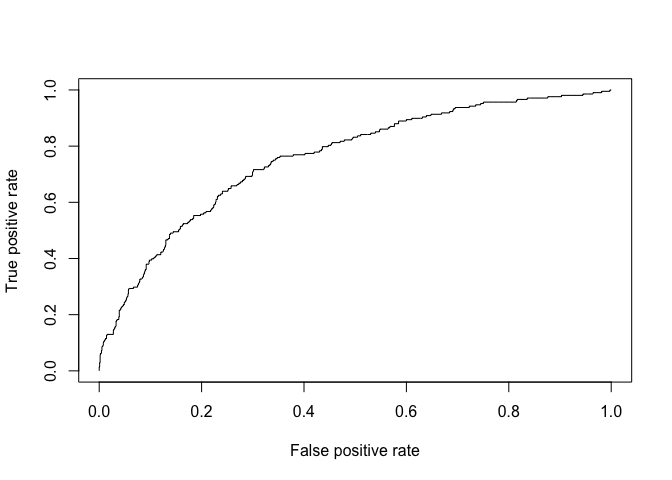

```r
library(ROCR)
pr3<-complete.cases(cbind(predict_test,test$TENCHD))
predict3 <- prediction(predict_test[pr3],test$TENCHD[pr3])
perf3 <- performance(predict3,x.measure="fpr",measure="tpr")
plot(perf3)
```

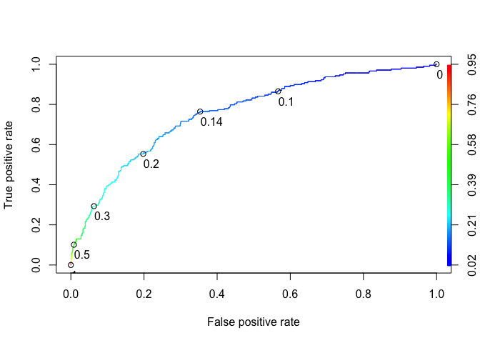

```r
plot(perf3,colorize=T,print.cutoffs.at=c(0,0.1,0.145,0.2,0.3,0.5,1),text.adj=c(-.02,1.7))
```

## 4.2 AUC

area under curve = 0.5 means random guessing area under curve = 1 means perfect model The result (AUC = 0.757) indicates that the model can distinguish between low and high risk patients better than random guessing.

```r
as.numeric(performance(predict3,measure="auc")@y.values) # just print AUC value
```

```
## [1] 0.7574258
```

```r
summary(model3)
```

```
##
## Call:
## glm(formula = TENCHD ~ SEX + AGE + SYSBP + CIGPDAY + GLUCOSE,
##     family = "binomial", data = training)
##
## Coefficients:
##              Estimate Std. Error z value Pr(>|z|)
## (Intercept) -7.160110   0.524258 -13.658  < 2e-16 ***
## SEX         -0.540547   0.126240  -4.282 1.85e-05 ***
## AGE          0.059845   0.007537   7.940 2.02e-15 ***
## SYSBP        0.016072   0.002573   6.247 4.18e-10 ***
## CIGPDAY      0.018223   0.005058   3.602 0.000315 ***
## GLUCOSE      0.009935   0.002303   4.314 1.61e-05 ***
## ---
## Signif. codes:  0 '***' 0.001 '**' 0.01 '*' 0.05 '.' 0.1 ' ' 1
##
## (Dispersion parameter for binomial family taken to be 1)
##
##     Null deviance: 2143.5  on 2496  degrees of freedom
## Residual deviance: 1929.3  on 2491  degrees of freedom
##   (259 observations deleted due to missingness)
## AIC: 1941.3
##
## Number of Fisher Scoring iterations: 5
```